# lab_5

Merly Klaas

11/2/2021

## 1. Start a new RStudio Project

1.1. Be sure to add a folder for “data” and “scripts”.

## 2. Data

2.1. Download the studentInfo.csv, studentAssessment.csv, and assessments data from the course website.

2.2. Place the files in the “data” folder in your project.

2.3. Read in the data.

```r
asses <- import(here("data", "assessments.csv"))
stu_asses <- import(here("data", "studentAssessment.csv"))
stu_info <- import(here("data", "studentInfo.csv"))
```

## 3. Join

3.1. Join the studentInfo data and the studentAssessment data. Name the joined data student.

```r
student <- inner_join(stu_info, stu_asses, by= "id_student")
```

```
## inner_join: added 4 columns (id_assessment, date_submitted, is_banked, score)
```

```
##             > rows only in x  (  5,847)
```

```
##             > rows only in y  (      0)
```

```
##             > matched rows     207,319    (includes duplicates)
```

```
##             >                 =========
```

```
##             > rows total       207,319
```

3.2. What key(s) were used in the join? id_student

3.3. How many rows are in this joined data? If that is different than the number of rows in the studentInfo data, why?

3.3. Join the newly created student data with the assessments data. Name the joined data student.

```r
student <- inner_join (student, asses, by = "id_assessment")
```

```
## inner_join: added 7 columns (code_module.x, code_presentation.x, code_module.y, code_presentation.y, assessment_type, …)
```

```
##             > rows only in x  (      0)
```

```
##             > rows only in y  (     18)
```

```
##             > matched rows     207,319
```

```
##             >                 =========
```

```
##             > rows total       207,319
```

3.4. What key(s) were used in the join? id_assessment

3.5. What new variables were added with this join? There are 7 columns added (code_module.x, code_presentation.x, code_module.y, code_presentation.y, assessment_type, date, and weight)

## 4. Wrangle

4.1. Create a new dataset named student_tma that consists only of TMA (Tutor Marked Assessment) assessments.

```r
student_tma <- student %>%
  filter(assessment_type == "TMA")
```

```
## filter: removed 89,244 rows (43%), 118,075 rows remaining
```

4.2. Create a new dataset named student_tma_max that contains the maximum (max()) TMA score for each student. (Note. Use filter rather than summarize.)

```r
student_tma_max <- student_tma %>%
  group_by (id_student) %>%
  filter(score == max(score))
```

```
## group_by: one grouping variable (id_student)
```

```
## filter (grouped): removed 88,909 rows (75%), 29,166 rows remaining
```

4.3. How many rows are in this joined data? What does each row represent? in student_tma there are 118,075 rows, each represents all TMA exam’s score for each student that had been taken multiple times. in student_tma_max there are 29,166 rows, each represents only the highest TMA exam’s score(s) each student has ever achieved.

4.4. Create a dataset named agg_tma_max that contains the mean TMA score by “highest_education”, “disability”, and “final_result.”

```r
agg_tma_max <- student_tma_max %>%
  group_by(highest_education, disability, final_result) %>%
  mutate( highest_education = factor(highest_education, levels = c("Post Graduate Qualification", "HE Qualification", "A Level or Equivalent", "Lower Than A Level", "No Formal quals"))) %>%
  summarize(mean = mean(score))
```

```
## group_by: 3 grouping variables (highest_education, disability, final_result)
```

```
## mutate (grouped): converted 'highest_education' from character to factor (0 new NA)
```

```
## summarize: now 34 rows and 4 columns, 2 group variables remaining (highest_education, disability)
```

6. Plot 6.1. Reproduce the following plot, using any theme and colors you want except for the defaults.

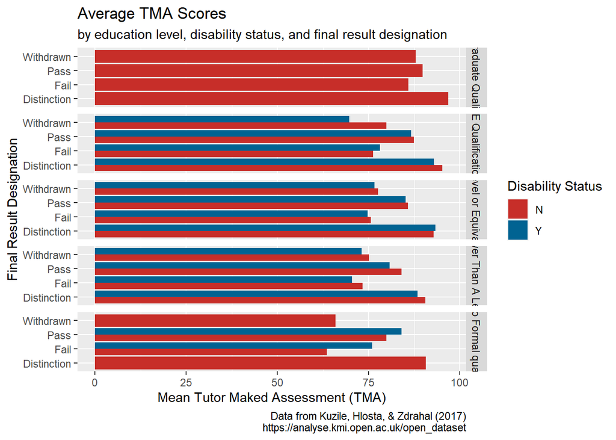

```r
  ggplot(agg_tma_max, aes(final_result, mean))+
  geom_col(aes(fill= disability) ,
          position = "dodge") +
  coord_flip()+
  facet_grid(rows = vars (highest_education)) +
  scale_fill_wsj()+
  labs (x= "Final Result Designation",
        y= "Mean Tutor Maked Assessment (TMA)" ,
        title = "Average TMA Scores",
        subtitle = "by education level, disability status, and final result designation" ,
        caption = "Data from Kuzile, Hlosta, & Zdrahal (2017)
        https://analyse.kmi.open.ac.uk/open_dataset",
        fill = "Disability Status"
          )
```